# Relationships Goldilocks Zone, Appendix

Larry Liu | www.mandatoryliposuction.com | www.hrlarry.com | hrlarry@stanford.edu

November 27, 2015

Notes:

This appendix is meant to supplement the post on the Relationships Goldilocks Zone on my blog at www.mandatoryliposuction.com.

If you’re running any of the code locally, you’ll need to have the ggplot2 library installed. If you want to create your own version of the GIFs seen in the blog post, you need to install ImageMagick and change the pathname in the final R block, as well as install the animation library.

All content copyrighted by Larry Liu and Mandatory Liposuction.

To get an understanding of how the activation discomfort works, here’s an illustration simulating two relationship conflicts, one that is below the negativity threshold and one that is above.

The first conflict has intensity 20, and the negativity threshold is 25. So, the relationship experiences escalated tension when it happens, and the conflict is not talked about and resolved:

```r
negThreshold = 25 # Negativity threshold
netHealth = .20 # Cumulative relationship tension decreases by 20% of conflict intensity

isolatedConflict = negThreshold - 5 # Conflict intensity below negativity threshold
```

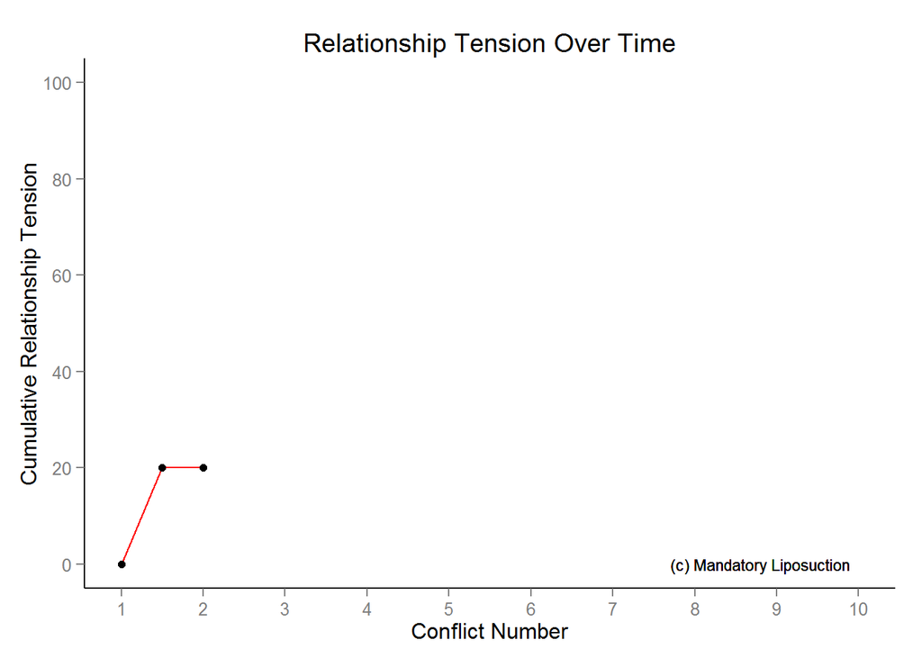

The second conflict has intensity 30. First, the conflict occurs:

```r
isolatedConflict2 = negThreshold + 5 # Conflict intensity above negativity threshold
```

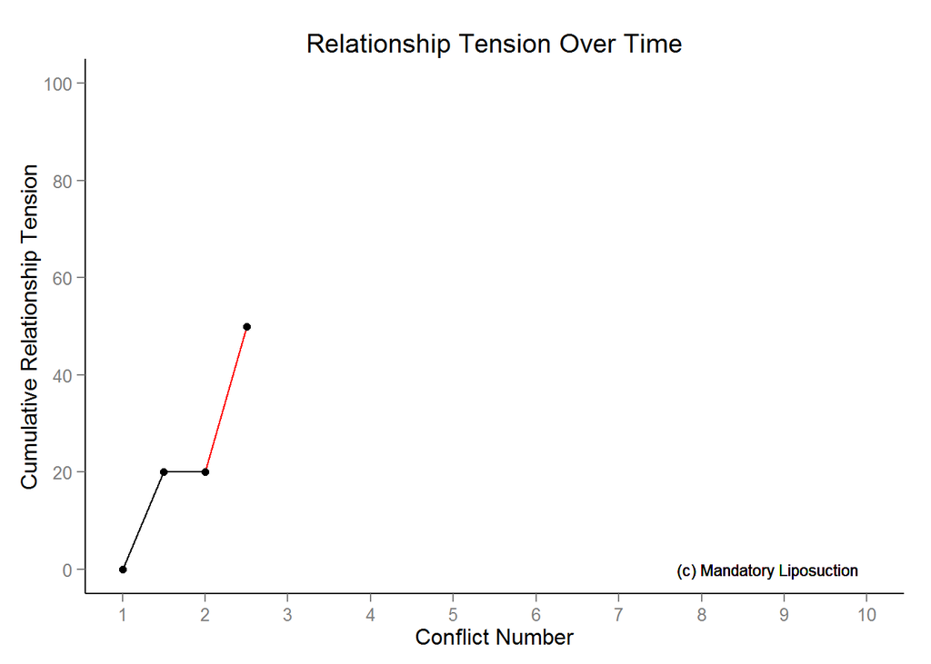

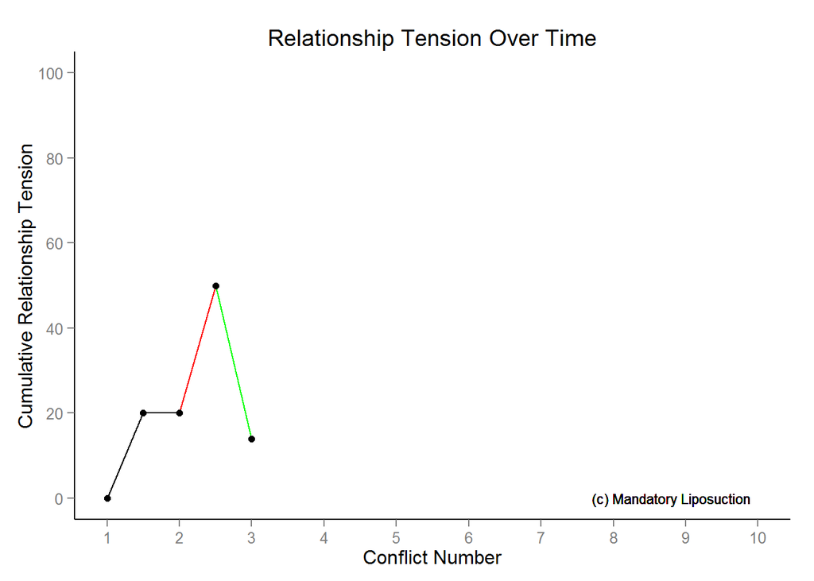

Now that we see how each individual relationship conflict can affect cumulative relationship tension, lets simulate an actual relationship!

Here are the first 10 elements of a vector of numbers that represents a sequence of relationship conflicts’ intensities. The intensities were generated sampling from an exponential distribution and then scaling the sample to span the range 1 to 100.

```r
numConflicts = 1000 # Number of conflicts to simulate
decayRate = .30 # Decay rate of exponential distribution
tensionLimit = 250 # Cumulative relationship tension limit
netHealth = .20 # Cumulative relationship tension decreases by 20% of conflict intensity
negThreshold = 10 # Negativity threshold

intensities = rexp(numConflicts, decayRate) # Sample from exponential distribution

scaleFactor = 99 / max(intensities) # Determine scale factor for sample to span 0 to 99

intensities = floor(intensities * scaleFactor) + 1 # Scale all samples to 1 to 100
```

```
##  [1]  8  8 25 15 44  1  6  9 12  2
```

```
##    Min. 1st Qu.  Median    Mean 3rd Qu.    Max.
##    1.00    5.00   11.00   15.84   21.00  100.00
```

To get a sense of what the distribution of samples look like, we can look at the frequency distribution of our samples.

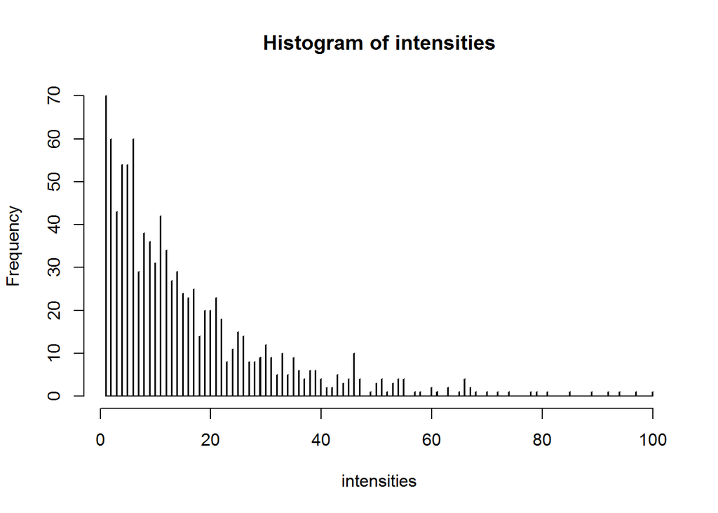

Alternatively, we can look at the conflicts in sorted order.

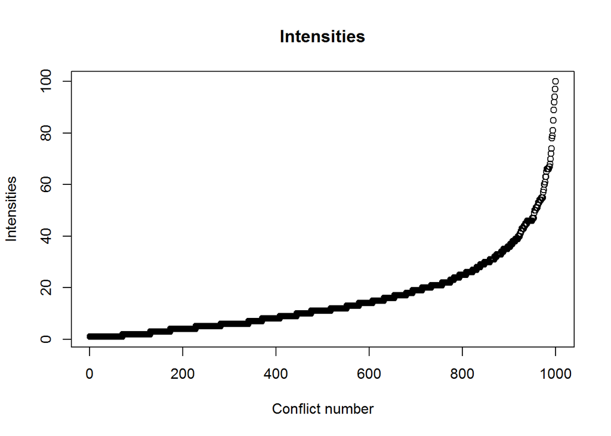

We now simulate how relationship tension changes over time in response to relationship conflicts given a particular negativity threshold.

How do we pick such a negativity threshold? A “good” negativity threshold does not diverge, i.e. has an expected net impact on relationship tension less than 0. We bootstrap from our sample, treating it as a full population even if its properties may not be consistent with the distribution we generated the sample from.

```r
expectedImpact <- function(conflictVector, threshold, netHealth){
  impactVector = ifelse(conflictVector>=threshold, floor(conflictVector*-1*netHealth), conflictVector)
  return (mean(impactVector))
}

possibleThresholds = c(1:100)
expectedImpactVector = c()
for(i in possibleThresholds){
  currExpectedImpact = expectedImpact(intensities, i, netHealth)
  if(currExpectedImpact < 0)
  expectedImpactVector = append(expectedImpactVector, currExpectedImpact)
}

maxGoodThreshold = length(expectedImpactVector)
print(paste("The highest negativity threshold that still converges is around", toString(maxGoodThreshold)))
```

```
## [1] "The highest negativity threshold that still converges is around 12"
```

We generate the cumulative relationship health graphs given negativity thresholds near the best negativity threshold.

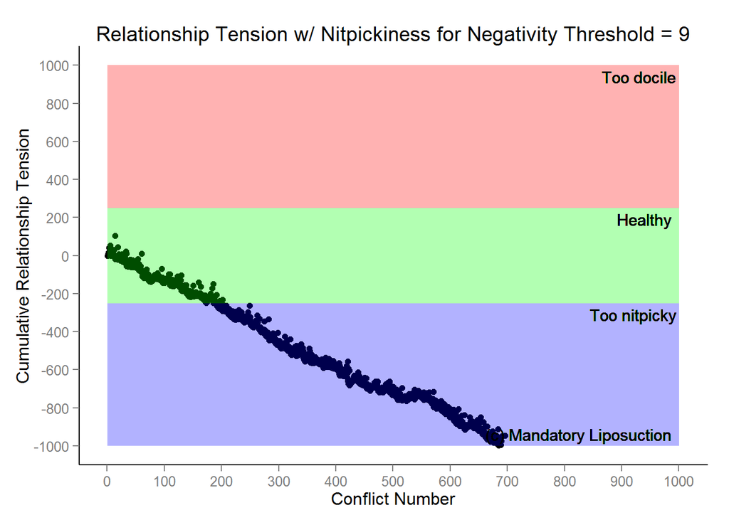

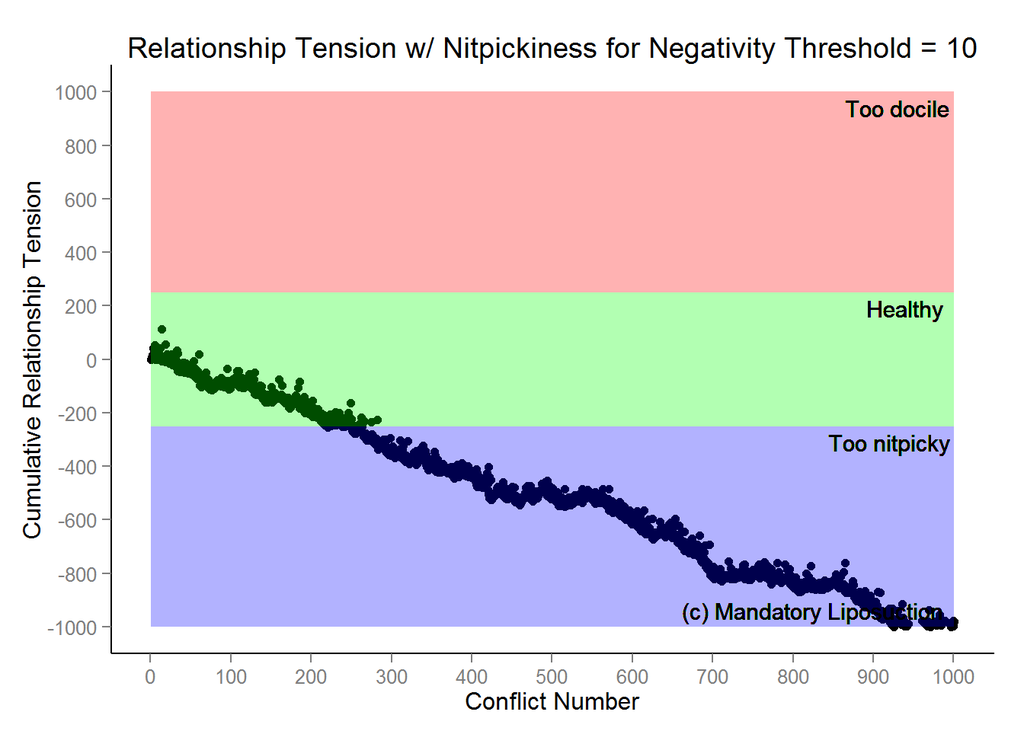

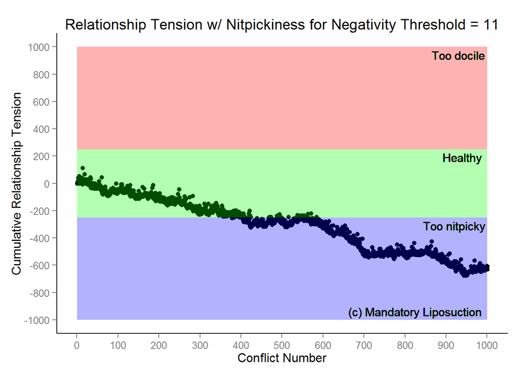

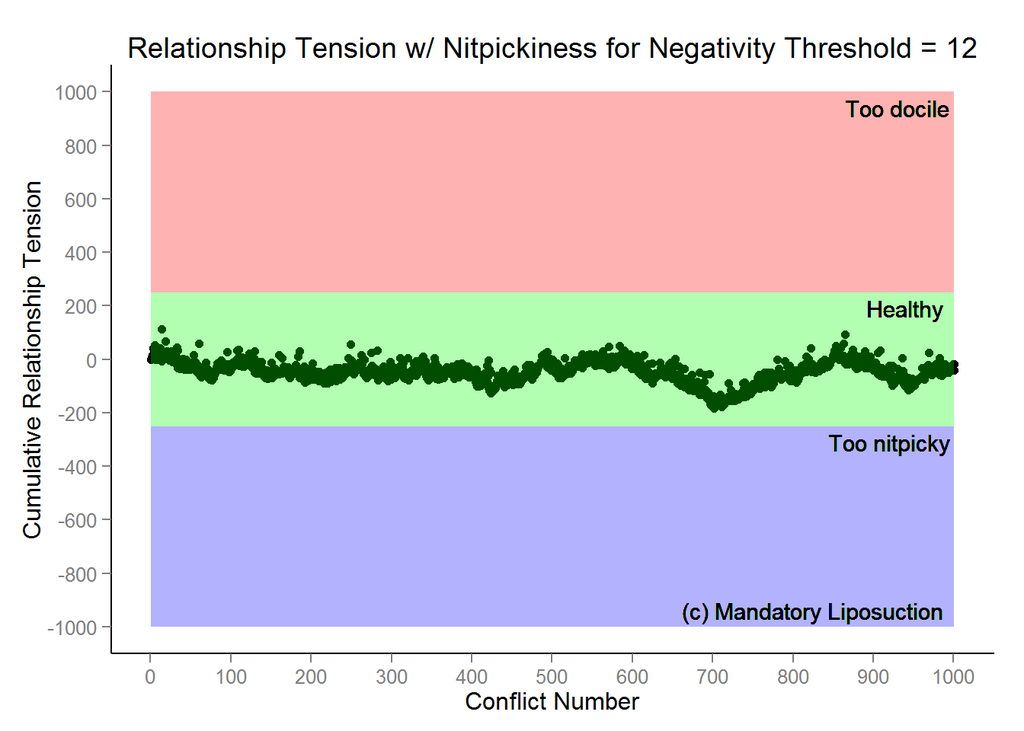

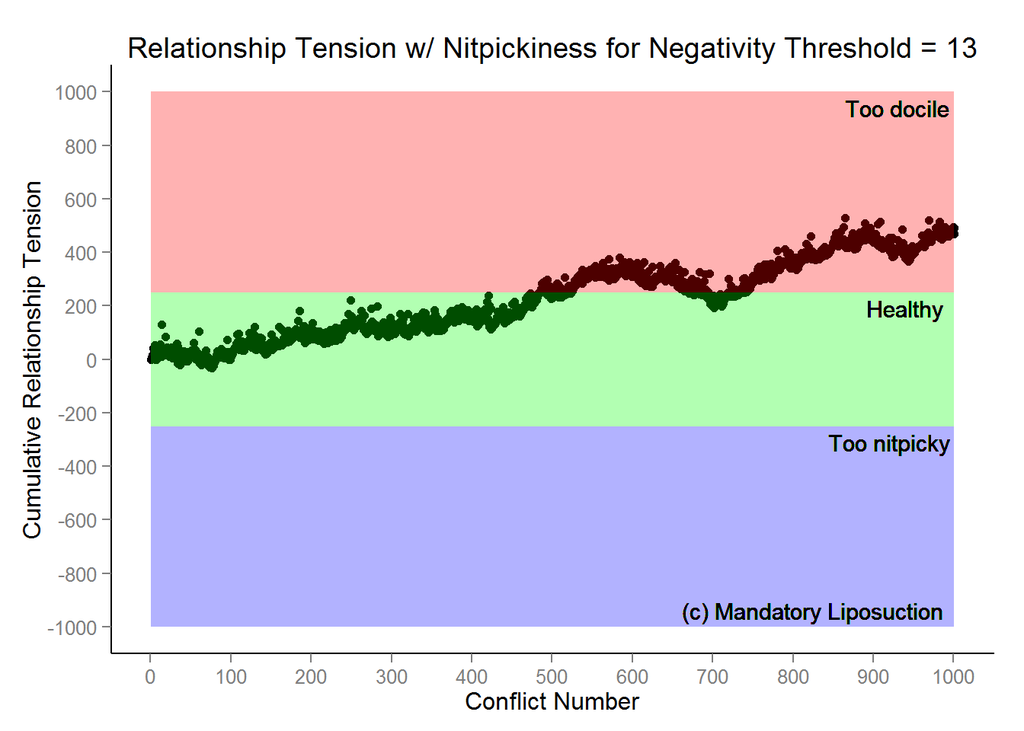

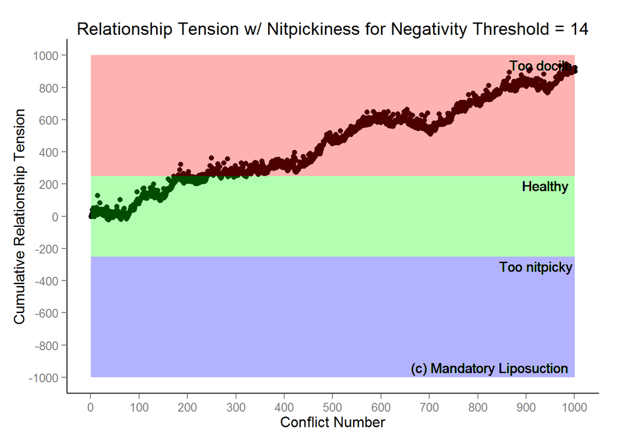

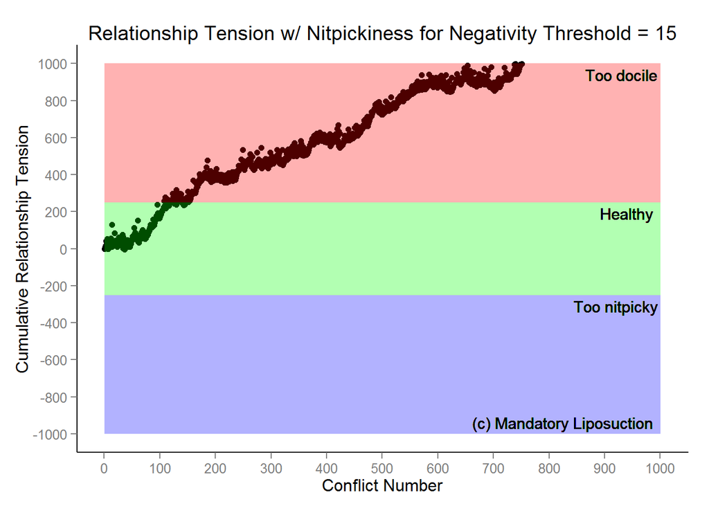